# Homework 3

Arman Aghamyan

February 21, 2019

*For this Homework, you are required to submit both Markdown and HTML files with your answers and code in it. Be sure that the .Rmd file is working, so when I run it, there would be no errors and represent the same information as HTML. Write your code and interpretations under each question. The interpretations of the results need to be written below or above all the charts, summaries, or tables. Do not remove problems from your Markdown file.*

Use biodata.csv dataset uploaded on Moodle to analyze the relationship between the presence of kidney disease and different factors. The description of the variables is given in a separate file. Pay close attention to the names of axes, titles, and labels.

**Problem 1. 2 pt.**

Load the file.

Get rid of variables which are irrelevant for logistic regression analysis using function select(). Also, skip variables which are absent in .txt file).

Check whether the data types are correct, if not make appropriate corrections assigning labels to each level according to the data description.

For all **numeric** variables replace missing values by column mean.

Create new dataset without missing data (remove observations with missing values for **categorical** variables)

How many variables and observations do you have before and now?

```r
library(MASS)
library(dplyr)
library(zoo)
bio<-read.csv("biodata.csv",na.strings = "?")
str(bio)
```

```
## 'data.frame':    381 obs. of  21 variables:
##  $ id   : int  1 2 3 4 5 6 7 8 9 10 ...
##  $ age  : int  48 7 62 48 51 60 68 24 52 53 ...
##  $ bp   : int  80 50 80 70 80 90 70 NA 100 90 ...
##  $ su   : int  0 0 3 0 0 0 0 4 0 0 ...
##  $ rbc  : Factor w/ 2 levels "abnormal","normal": 1 1 2 2 2 1 1 2 2 1 ...
##  $ ba   : Factor w/ 2 levels "notpresent","present": 1 1 1 1 1 1 1 1 1 1 ...
##  $ bgr  : int  121 NA 423 117 106 74 100 410 138 70 ...
##  $ sc   : num  1.2 0.8 1.8 3.8 1.4 1.1 24 1.1 1.9 7.2 ...
##  $ sod  : num  NA NA NA 111 NA 142 104 NA NA 114 ...
##  $ pot  : num  NA NA NA 2.5 NA 3.2 4 NA NA 3.7 ...
##  $ hemo : num  15.4 11.3 9.6 11.2 11.6 12.2 12.4 12.4 10.8 9.5 ...
##  $ pcv  : int  44 38 31 32 35 39 36 44 33 29 ...
##  $ wbcc : int  7800 6000 7500 6700 7300 7800 NA 6900 9600 12100 ...
##  $ rbcc : num  5.2 NA NA 3.9 4.6 4.4 NA 5 4 3.7 ...
##  $ htn  : Factor w/ 2 levels "no","yes": 2 1 1 2 1 2 1 1 2 2 ...
##  $ dm   : Factor w/ 2 levels "no","yes": 2 1 2 1 1 2 1 2 2 2 ...
##  $ cad  : Factor w/ 2 levels "no","yes": 1 1 1 1 1 1 1 1 1 1 ...
##  $ appet: Factor w/ 2 levels "good","poor": 1 1 2 2 1 1 1 1 1 2 ...
##  $ pe   : Factor w/ 2 levels "no","yes": 1 1 1 2 1 2 1 2 1 1 ...
##  $ ane  : Factor w/ 2 levels "no","yes": 1 1 2 2 1 1 1 1 2 2 ...
##  $ class: int  1 1 1 1 1 1 1 1 1 1 ...
```

```r
any(duplicated(bio$id))
```

```
## [1] FALSE
```

```r
bio<-select(bio,-c(id,sc, pcv,pe))
any(is.na(bio))
```

```
## [1] TRUE
```

```r
bio$su<-ordered(bio$su,levels=c(0,1,2,3,4,5))
bio$class<-as.factor(bio$class)
nm<- sapply(bio, is.numeric)
bio[nm] <- lapply(bio[nm], na.aggregate)
bio[nm]<-round(bio[nm])
bio<-na.omit(bio)
str(bio)
```

```
## 'data.frame':    322 obs. of  17 variables:
##  $ age  : num  48 7 62 48 51 60 68 24 52 53 ...
##  $ bp   : num  80 50 80 70 80 90 70 76 100 90 ...
##  $ su   : Ord.factor w/ 6 levels "0"<"1"<"2"<"3"<..: 1 1 4 1 1 1 1 5 1 1 ...
##  $ rbc  : Factor w/ 2 levels "abnormal","normal": 1 1 2 2 2 1 1 2 2 1 ...
##  $ ba   : Factor w/ 2 levels "notpresent","present": 1 1 1 1 1 1 1 1 1 1 ...
##  $ bgr  : num  121 146 423 117 106 74 100 410 138 70 ...
##  $ sod  : num  138 138 138 111 138 142 104 138 138 114 ...
##  $ pot  : num  5 5 5 2 5 3 4 5 5 4 ...
##  $ hemo : num  15 11 10 11 12 12 12 12 11 10 ...
##  $ wbcc : num  7800 6000 7500 6700 7300 ...
##  $ rbcc : num  5 5 5 4 5 4 5 5 4 4 ...
##  $ htn  : Factor w/ 2 levels "no","yes": 2 1 1 2 1 2 1 1 2 2 ...
##  $ dm   : Factor w/ 2 levels "no","yes": 2 1 2 1 1 2 1 2 2 2 ...
##  $ cad  : Factor w/ 2 levels "no","yes": 1 1 1 1 1 1 1 1 1 1 ...
##  $ appet: Factor w/ 2 levels "good","poor": 1 1 2 2 1 1 1 1 1 2 ...
##  $ ane  : Factor w/ 2 levels "no","yes": 1 1 2 2 1 1 1 1 2 2 ...
##  $ class: Factor w/ 2 levels "0","1": 2 2 2 2 2 2 2 2 2 2 ...
##  - attr(*, "na.action")= 'omit' Named int  20 29 38 51 58 60 61 78 86 87 ...
##   ..- attr(*, "names")= chr  "20" "29" "38" "51" ...
```

**Problem 2. 3 pt.**

1. Check the relationship between each numeric variable and the presence of kidney disease. Save only the two most important numeric variables using boxplots. Comment on it.
2. Use the glm() function to perform a logistic regression with Class as the response and one of **numeric** variables as the predictor (use results of 2a). Use the summary() function to print the result. Is your explanatory variable significant? Why?
3. Plot the response and the predictor, and sigmoid line. For this task, you should create a sequence of x values and predict your model for them, then add to your graph

Problem 2 A)

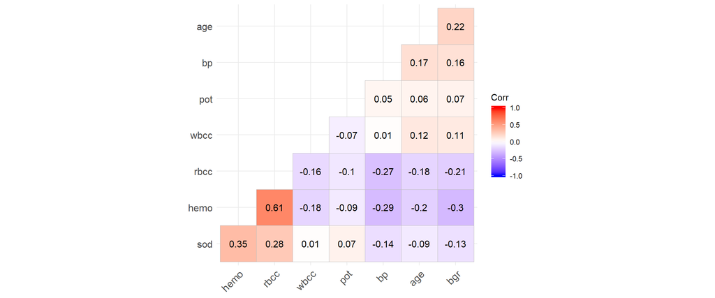

```r
library(ggplot2)
library(gridExtra)
library(ggcorrplot)

num<-bio%>% select_if(is.numeric)
ggcorrplot(cor(num), hc.order = TRUE, type = "lower",
   lab = TRUE)
```

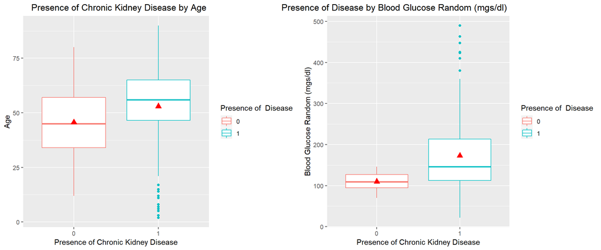

```r
b1<-ggplot(data = bio, aes(y =age, x = class,color = class))+
  geom_boxplot()+
  scale_x_discrete(labels= levels(bio$class) )+
  stat_summary(fun.y = "mean",geom = 'point',col='red', shape=17, size=3)+
  labs(title ="Presence of Chronic Kidney Disease by Age " ,color =  "Presence of  Disease",y='Age',x="Presence of Chronic Kidney Disease")+
  theme(plot.title = element_text(hjust = 1))




b2<-ggplot(data = bio, aes(y =bgr, x = class,color = class))+
  geom_boxplot()+
  scale_x_discrete(labels= levels(bio$class) )+
  stat_summary(fun.y = "mean",geom = 'point',col='red', shape=17, size=3)+
  labs(title ="Presence of Disease by Blood Glucose Random (mgs/dl) " ,color =  "Presence of  Disease",y='Blood Glucose Random (mgs/dl)',x="Presence of Chronic Kidney Disease")+
  theme(plot.title = element_text(hjust = 1))


grid.arrange(b1,b2,nrow=1)
```

People who has the Kidney disease tend to have higher blood glucose random counts than people who doesn’t have illness. Poeple whoes age is over 50 tend to have kidney disease than more young people.But we have outliers here.

```r
library(glmnet)
library(caret)
prop.table((table(bio$class)))
```

```
##
##        0        1
## 0.431677 0.568323
```

```r
set.seed(1)
model1<-glm(class~bgr,data=bio,family ='binomial')
summary(model1)
```

```
##
## Call:
## glm(formula = class ~ bgr, family = "binomial", data = bio)
##
## Deviance Residuals:
##     Min       1Q   Median       3Q      Max
## -1.5310  -0.9839   0.1306   0.8611   2.4552
##
## Coefficients:
##              Estimate Std. Error z value Pr(>|z|)
## (Intercept) -3.631494   0.572289  -6.346 2.22e-10 ***
## bgr          0.030361   0.004646   6.535 6.34e-11 ***
## ---
## Signif. codes:  0 '***' 0.001 '**' 0.01 '*' 0.05 '.' 0.1 ' ' 1
##
## (Dispersion parameter for binomial family taken to be 1)
##
##     Null deviance: 440.36  on 321  degrees of freedom
## Residual deviance: 346.92  on 320  degrees of freedom
## AIC: 350.92
##
## Number of Fisher Scoring iterations: 6
```

```r
exp(coef(model1))
```

```
## (Intercept)         bgr
##  0.02647661  1.03082695
```

```r
range(bio$bgr)
```

```
## [1]  22 490
```

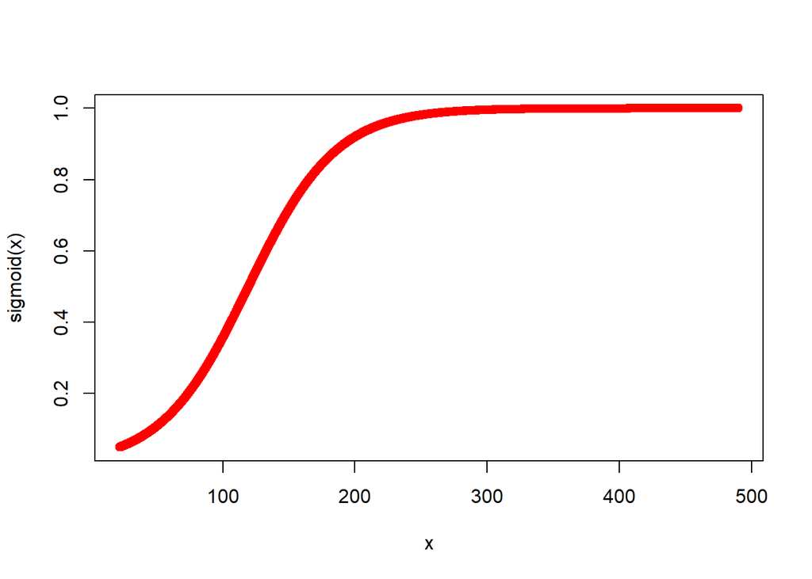

```r
sigmoid <- function (x) 1 / (1 + exp(3.631494- 0.030361 * x))
x<-seq(22,490,0.01)
plot(x, sigmoid(x), col='red')
```

**Problem 3. 4 pt.**

Use the glm() function to perform a logistic regression with Class as the response and one of **categorical** variables as the predictor (chose significant one). Use the summary() function to print the results.

1. Interpret the coefficients of the explanatory variable in terms of absolute and exponential values?
2. Compute probability for the base value of your explanatory variable. Comment on it.
3. What do Null deviance and residual deviance of summary output mean?
4. Calculate the value of the exponent of the b1 coefficient using only your data and functions addmargins() and table().

```r
#A
model2<-glm(class~rbc,bio,family ='binomial')
summary(model2)
```

```
##
## Call:
## glm(formula = class ~ rbc, family = "binomial", data = bio)
##
## Deviance Residuals:
##     Min       1Q   Median       3Q      Max
## -2.0963  -1.0834   0.4854   1.2744   1.2744
##
## Coefficients:
##             Estimate Std. Error z value Pr(>|z|)
## (Intercept)   2.0794     0.3354   6.200 5.65e-10 ***
## rbcnormal    -2.3045     0.3605  -6.393 1.63e-10 ***
## ---
## Signif. codes:  0 '***' 0.001 '**' 0.01 '*' 0.05 '.' 0.1 ' ' 1
##
## (Dispersion parameter for binomial family taken to be 1)
##
##     Null deviance: 440.36  on 321  degrees of freedom
## Residual deviance: 381.49  on 320  degrees of freedom
## AIC: 385.49
##
## Number of Fisher Scoring iterations: 4
```

```r
coef(model2)
```

```
## (Intercept)   rbcnormal
##    2.079442   -2.304525
```

```r
exp(coef(model2))
```

```
## (Intercept)   rbcnormal
##   8.0000000   0.0998062
```

```r
probabnormal<-predict(model2,newdata = data.frame(rbc='abnormal'),type = 'response')
print(probabnormal)
```

```
##         1
## 0.8888889
```

```r
#D
addmargins(table(bio$rbc,bio$class))
```

```
##
##              0   1 Sum
##   abnormal  10  80  90
##   normal   129 103 232
##   Sum      139 183 322
```

```r
psn<-103/232
psabn<-80/90
oddsnormal<-psn/(1-psn)
oddsabnormal<-psabn/(1-psabn)
oddsratio<-oddsnormal/oddsabnormal
print(oddsratio)
```

```
## [1] 0.0998062
```

**Problem 4. 4 pt.**

1. Use the full data set to perform the model with Class as a dependent variable. Use the stepAIC() function to obtain the best model based on AIC criteria. Use the backward selection procedure. Do not show the output.
2. Remove all non-significant variables from the last model. Show only the best model(all variables must be significant at least at the level 0.01). Use the summary() function to print the result.
3. Pick your own new observation and predict the y value. Comment on it.
4. Is it possible to calculate R square for logistic regression?

```r
summary(model_AIC)
```

```
##
## Call:
## glm(formula = class ~ age + bp + rbc + bgr + sod + hemo + wbcc +
##     htn + cad, family = "binomial", data = bio)
##
## Deviance Residuals:
##      Min        1Q    Median        3Q       Max
## -1.75886  -0.04965   0.00000   0.00002   3.05297
##
## Coefficients:
##               Estimate Std. Error z value Pr(>|z|)
## (Intercept)  3.164e+01  1.013e+01   3.123  0.00179 **
## age         -5.296e-02  2.491e-02  -2.126  0.03348 *
## bp           1.101e-01  4.266e-02   2.582  0.00983 **
## rbcnormal   -4.201e+00  1.250e+00  -3.360  0.00078 ***
## bgr          5.665e-02  1.384e-02   4.094 4.24e-05 ***
## sod         -9.868e-02  6.273e-02  -1.573  0.11571
## hemo        -2.255e+00  4.629e-01  -4.873 1.10e-06 ***
## wbcc         3.548e-04  2.357e-04   1.505  0.13231
## htnyes       2.030e+01  1.729e+03   0.012  0.99063
## cadyes      -4.006e+00  1.857e+00  -2.157  0.03101 *
## ---
## Signif. codes:  0 '***' 0.001 '**' 0.01 '*' 0.05 '.' 0.1 ' ' 1
##
## (Dispersion parameter for binomial family taken to be 1)
##
##     Null deviance: 440.356  on 321  degrees of freedom
## Residual deviance:  59.386  on 312  degrees of freedom
## AIC: 79.386
##
## Number of Fisher Scoring iterations: 20
```

```r
model_best<-glm(class~rbc+bgr+hemo+bp+cad+sod,data=bio,family="binomial")
summary(model_best)
```

```
##
## Call:
## glm(formula = class ~ rbc + bgr + hemo + bp + cad + sod, family = "binomial",
##     data = bio)
##
## Deviance Residuals:
##      Min        1Q    Median        3Q       Max
## -2.16852  -0.09237   0.00020   0.02973   2.90270
##
## Coefficients:
##             Estimate Std. Error z value Pr(>|z|)
## (Intercept) 41.49170    9.46026   4.386 1.16e-05 ***
## rbcnormal   -3.76510    0.91195  -4.129 3.65e-05 ***
## bgr          0.04673    0.01038   4.503 6.70e-06 ***
## hemo        -2.12194    0.36091  -5.879 4.12e-09 ***
## bp           0.07574    0.03188   2.376  0.01750 *
## cadyes      -2.87807    1.41501  -2.034  0.04196 *
## sod         -0.14937    0.05534  -2.699  0.00696 **
## ---
## Signif. codes:  0 '***' 0.001 '**' 0.01 '*' 0.05 '.' 0.1 ' ' 1
##
## (Dispersion parameter for binomial family taken to be 1)
##
##     Null deviance: 440.356  on 321  degrees of freedom
## Residual deviance:  84.345  on 315  degrees of freedom
## AIC: 98.345
##
## Number of Fisher Scoring iterations: 9
```

```r
predict(model_best,newdata = data.frame(sod=mean(bio$sod),rbc='abnormal',bgr=mean(bio$bgr),hemo=mean(bio$hemo),bp=mean(bio$bp),cad='no'),type = 'response')
```

```
##         1
## 0.9983222
```

B)After removing one of the non_significant variables,I noticed that age became non-significant.